# Life Policy Book Analysis: Detailed Lapse Analysis

Mick Cooney mickcooney@gmail.com

2018-01-04

Having introduced the concept of using survival analysis to investigate lapse risks we now perform a much more in-depth analysis using various additional techniques.

# 1 Load Training/Test Data

We first load the training and test data into separate tables.

```r
snapshot_date <- as.Date('2015-12-31')

train_tbl <- read_feather("data/protection_train.feather")
test_tbl  <- read_feather('data/protection_test.feather')

train_tbl %>% glimpse
```

```
## Observations: 401,865
## Variables: 28
## $ policy_id               <chr> "C010000259", "C010000790", "C010001124", "C010001209...
## $ countyname              <chr> "Cavan County", "Wicklow County", "South Dublin", "Fi...
## $ edname                  <chr> "Tullyvin East", "Bray No. 3", "Tallaght-Jobstown", "...
## $ nuts3name               <chr> "Border", "Mid-East", "Dublin", "Dublin", "Mid-West",...
## $ sa_id                   <chr> "A027090001", "A257017025", "A267140026", "A267040036...
## $ cluster_id              <fct> n6_c1, n6_c5, n6_c5, n6_c5, n6_c1, n6_c1, n6_c2, n6_c...
## $ prod_type               <chr> "protection", "protection", "protection", "protection...
## $ prem_type               <chr> "RP", "RP", "RP", "RP", "RP", "RP", "RP", "RP", "RP",...
## $ prem_freq               <int> 12, 12, 12, 12, 12, 12, 12, 12, 12, 12, 12, 12, 12, 1...
## $ prem_ape                <dbl> 1772.83, 968.72, 3124.86, 1199.13, 8020.28, 5210.64, ...
## $ prem_risk               <dbl> 1266.308, 691.944, 2232.045, 856.525, 5728.771, 3721....
## $ policy_startdate        <date> 1990-01-02, 1990-01-02, 1990-01-03, 1990-01-03, 1990...
## $ policy_enddate          <date> 2010-01-02, 2010-01-02, 2005-01-03, 2010-01-03, 2004...
## $ policy_duration         <int> 20, 20, 15, 20, 14, 10, 20, 5, 20, 20, 15, 5, 10, 20,...
## $ mort_rating             <int> 200, 100, 100, 100, 150, 200, 100, 100, 100, 100, 150...
## $ sum_assured             <dbl> 150000, 250000, 500000, 400000, 250000, 200000, 10000...
## $ dob_life1               <date> 1955-12-23, 1946-12-10, 1938-04-24, 1950-01-12, 1928...
## $ gender_life1            <fct> F, M, F, M, M, M, M, M, M, M, M, F, F, M, M, F, F, M,...
## $ smoker_life1            <fct> S, N, N, N, Q, S, N, N, N, N, Q, S, Q, Q, N, S, S, Q,...
## $ isjointlife             <lgl> FALSE, FALSE, FALSE, FALSE, FALSE, TRUE, FALSE, FALSE...
## $ islifeonly              <lgl> FALSE, TRUE, TRUE, TRUE, TRUE, TRUE, TRUE, TRUE, TRUE...
## $ mortgage_status         <fct> MORTFULL, MORTDECR, MORTDECR, MORTDECR, TERM, TERM, M...
## $ policy_status           <chr> "completed", "lapsed", "completed", "completed", "com...
## $ policy_statuschangedate <date> 2010-01-02, 1995-07-02, 2005-01-03, 2010-01-03, 2004...
## $ lapsed                  <lgl> FALSE, TRUE, FALSE, FALSE, FALSE, FALSE, FALSE, FALSE...
## $ age_at_data_snapshot    <dbl> 60.0219, 69.0568, 77.6865, 65.9658, 86.9979, 78.4969,...
## $ age_at_policy_start     <dbl> 34.0287, 43.0637, 51.6961, 39.9754, 61.0075, 52.5065,...
## $ month_reached           <int> 240, 66, 180, 240, 168, 120, 240, 60, 188, 57, 37, 7,...
```

```r
test_tbl  %>% glimpse
```

```
## Observations: 267,911
## Variables: 28
## $ policy_id               <chr> "C010000201", "C010000424", "C010000928", "C010000934...
## $ countyname              <chr> "South Dublin", "Donegal County", "Wicklow County", "...
## $ edname                  <chr> "Lucan-Esker", "Killybegs", "Kilcoole", "St. Peter's"...
## $ nuts3name               <chr> "Dublin", "Border", "Mid-East", "Border", "Dublin", "...
## $ sa_id                   <chr> "A267100077", "A057096009", "A257048009", "A147035021...
## $ cluster_id              <fct> n6_c5, n6_c2, n6_c5, n6_c3, n6_c5, n6_c5, n6_c2, n6_c...
## $ prod_type               <chr> "protection", "protection", "protection", "protection...
## $ prem_type               <chr> "RP", "RP", "RP", "RP", "RP", "RP", "RP", "RP", "RP",...
## $ prem_freq               <int> 12, 12, 12, 12, 12, 12, 12, 12, 12, 12, 12, 12, 12, 1...
## $ prem_ape                <dbl> 2825.19, 286.13, 2135.58, 2299.68, 577.73, 338.21, 13...
## $ prem_risk               <dbl> 2017.991, 204.378, 1525.415, 1642.631, 412.666, 241.5...
## $ policy_startdate        <date> 1990-01-02, 1990-01-02, 1990-01-02, 1990-01-02, 1990...
## $ policy_enddate          <date> 2010-01-02, 2010-01-02, 2010-01-02, 2000-01-02, 2010...
## $ policy_duration         <int> 20, 20, 20, 10, 20, 10, 20, 20, 20, 10, 15, 20, 10, 1...
## $ mort_rating             <int> 200, 150, 100, 200, 150, 100, 150, 150, 150, 100, 100...
## $ sum_assured             <dbl> 150000, 350000, 300000, 300000, 100000, 200000, 20000...
## $ dob_life1               <date> 1936-05-27, 1973-05-17, 1939-05-09, 1945-09-05, 1960...
## $ gender_life1            <fct> M, M, M, M, F, M, F, F, F, M, M, F, M, M, M, M, F, M,...
## $ smoker_life1            <fct> S, Q, N, S, Q, N, Q, Q, Q, N, N, Q, S, S, N, N, N, Q,...
## $ isjointlife             <lgl> FALSE, FALSE, FALSE, FALSE, FALSE, FALSE, FALSE, TRUE...
## $ islifeonly              <lgl> TRUE, TRUE, TRUE, TRUE, FALSE, TRUE, TRUE, TRUE, TRUE...
## $ mortgage_status         <fct> MORTDECR, MORTDECR, MORTDECR, TERM, MORTFULL, TERM, M...
## $ policy_status           <chr> "completed", "completed", "lapsed", "lapsed", "lapsed...
## $ policy_statuschangedate <date> 2010-01-02, 2010-01-02, 1991-09-02, 1990-05-02, 2006...
## $ lapsed                  <lgl> FALSE, FALSE, TRUE, TRUE, TRUE, FALSE, TRUE, FALSE, T...
## $ age_at_data_snapshot    <dbl> 79.5948, 42.6229, 76.6461, 70.3190, 55.7180, 59.9398,...
## $ age_at_policy_start     <dbl> 53.6016, 16.6297, 50.6530, 44.3258, 29.7248, 33.9466,...
## $ month_reached           <int> 240, 240, 20, 4, 194, 120, 98, 240, 2, 120, 4, 240, 1...
```

We do a quick check to ensure that there are no updates in the data after the snapshot date:

```r
train_tbl %>%
    filter(policy_statuschangedate >= snapshot_date ||
           policy_startdate        >= snapshot_date
           ) %>%
    glimpse
```

```
## Observations: 0
## Variables: 28
## $ policy_id               <chr>
## $ countyname              <chr>
## $ edname                  <chr>
## $ nuts3name               <chr>
## $ sa_id                   <chr>
## $ cluster_id              <fct>
## $ prod_type               <chr>
## $ prem_type               <chr>
## $ prem_freq               <int>
## $ prem_ape                <dbl>
## $ prem_risk               <dbl>
## $ policy_startdate        <date>
## $ policy_enddate          <date>
## $ policy_duration         <int>
## $ mort_rating             <int>
## $ sum_assured             <dbl>
## $ dob_life1               <date>
## $ gender_life1            <fct>
## $ smoker_life1            <fct>
## $ isjointlife             <lgl>
## $ islifeonly              <lgl>
## $ mortgage_status         <fct>
## $ policy_status           <chr>
## $ policy_statuschangedate <date>
## $ lapsed                  <lgl>
## $ age_at_data_snapshot    <dbl>
## $ age_at_policy_start     <dbl>
## $ month_reached           <int>
```

```r
test_tbl %>%
    filter(policy_statuschangedate >= snapshot_date ||
           policy_startdate        >= snapshot_date
           ) %>%
    glimpse
```

```
## Observations: 0
## Variables: 28
## $ policy_id               <chr>
## $ countyname              <chr>
## $ edname                  <chr>
## $ nuts3name               <chr>
## $ sa_id                   <chr>
## $ cluster_id              <fct>
## $ prod_type               <chr>
## $ prem_type               <chr>
## $ prem_freq               <int>
## $ prem_ape                <dbl>
## $ prem_risk               <dbl>
## $ policy_startdate        <date>
## $ policy_enddate          <date>
## $ policy_duration         <int>
## $ mort_rating             <int>
## $ sum_assured             <dbl>
## $ dob_life1               <date>
## $ gender_life1            <fct>
## $ smoker_life1            <fct>
## $ isjointlife             <lgl>
## $ islifeonly              <lgl>
## $ mortgage_status         <fct>
## $ policy_status           <chr>
## $ policy_statuschangedate <date>
## $ lapsed                  <lgl>
## $ age_at_data_snapshot    <dbl>
## $ age_at_policy_start     <dbl>
## $ month_reached           <int>
```

To facilitate faster computation of whatever models we choose to fit, we randomly sample data

```r
use_train_tbl <- train_tbl %>%
    sample_n(50000)
```

# 2 Basic Cox-PH Model

We return to investigating lapses using a basic Cox-PH model, so we start back with that model.

As a reference model, we use the model with gender, smoker and the cluster as a baseline model.

```r
reference_model_coxph <- coxph(
    Surv(month_reached, lapsed) ~ gender_life1 + smoker_life1 + cluster_id
   ,data = use_train_tbl
)

reference_model_coxph %>% summary()
```

```
## Call:
## coxph(formula = Surv(month_reached, lapsed) ~ gender_life1 +
##     smoker_life1 + cluster_id, data = use_train_tbl)
##
##   n= 50000, number of events= 19742
##
##                     coef exp(coef) se(coef)     z Pr(>|z|)
## gender_life1F   -0.12872   0.87922  0.01601 -8.04  8.9e-16 ***
## smoker_life1S   -0.01950   0.98069  0.01761 -1.11     0.27
## smoker_life1Q    0.29250   1.33978  0.01722 16.99  < 2e-16 ***
## cluster_idn6_c5  0.42388   1.52787  0.01964 21.58  < 2e-16 ***
## cluster_idn6_c1  0.00275   1.00275  0.02532  0.11     0.91
## cluster_idn6_c2 -0.01311   0.98698  0.02353 -0.56     0.58
## cluster_idn6_c3  0.00406   1.00407  0.03085  0.13     0.90
## cluster_idn6_c4 -0.26047   0.77069  0.02852 -9.13  < 2e-16 ***
## ---
## Signif. codes:  0 '***' 0.001 '**' 0.01 '*' 0.05 '.' 0.1 ' ' 1
##
##                 exp(coef) exp(-coef) lower .95 upper .95
## gender_life1F       0.879      1.137     0.852     0.907
## smoker_life1S       0.981      1.020     0.947     1.015
## smoker_life1Q       1.340      0.746     1.295     1.386
## cluster_idn6_c5     1.528      0.655     1.470     1.588
## cluster_idn6_c1     1.003      0.997     0.954     1.054
## cluster_idn6_c2     0.987      1.013     0.943     1.034
## cluster_idn6_c3     1.004      0.996     0.945     1.067
## cluster_idn6_c4     0.771      1.298     0.729     0.815
##
## Concordance= 0.57  (se = 0.002 )
## Rsquare= 0.027   (max possible= 1 )
## Likelihood ratio test= 1387  on 8 df,   p=0
## Wald test            = 1429  on 8 df,   p=0
## Score (logrank) test = 1453  on 8 df,   p=0
```

```r
reference_model_coxph %>% tidy()
```

```
##              term    estimate std.error statistic     p.value   conf.low  conf.high
## 1   gender_life1F -0.12871897 0.0160125 -8.038646 8.88178e-16 -0.1601029 -0.0973350
## 2   smoker_life1S -0.01949872 0.0176127 -1.107083 2.68258e-01 -0.0540190  0.0150215
## 3   smoker_life1Q  0.29250479 0.0172204 16.985911 0.00000e+00  0.2587534  0.3262562
## 4 cluster_idn6_c5  0.42387772 0.0196391 21.583361 0.00000e+00  0.3853858  0.4623696
## 5 cluster_idn6_c1  0.00274538 0.0253206  0.108425 9.13659e-01 -0.0468822  0.0523729
## 6 cluster_idn6_c2 -0.01310756 0.0235255 -0.557165 5.77415e-01 -0.0592166  0.0330015
## 7 cluster_idn6_c3  0.00405980 0.0308520  0.131589 8.95309e-01 -0.0564091  0.0645287
## 8 cluster_idn6_c4 -0.26047169 0.0285160 -9.134245 0.00000e+00 -0.3163619 -0.2045815
```

```r
reference_model_coxph %>% glance()
```

```
##       n nevent statistic.log p.value.log statistic.sc p.value.sc statistic.wald
## 1 50000  19742       1387.23           0      1452.78          0         1428.6
##   p.value.wald r.squared r.squared.max concordance std.error.concordance  logLik    AIC
## 1            0 0.0273632      0.999699    0.570114            0.00221156 -202030 404076
##      BIC
## 1 404139
```

While we have established that this model is not perfect due to the the covariates not having a time-independent effect on the lapse rate, it is still useful as a benchmark model for comparison purposes.

It is also simple, having just three covariates.

## 2.1 Adding Covariates

We add a number of extra covariates to the model to see what effect it has.

```r
basic_01_coxph <- coxph(
    Surv(month_reached, lapsed) ~ gender_life1 + smoker_life1 + cluster_id +
        mortgage_status + log(prem_ape) + age_at_policy_start + isjointlife
   ,data = use_train_tbl
)

basic_01_coxph %>% summary()
```

```
## Call:
## coxph(formula = Surv(month_reached, lapsed) ~ gender_life1 +
##     smoker_life1 + cluster_id + mortgage_status + log(prem_ape) +
##     age_at_policy_start + isjointlife, data = use_train_tbl)
##
##   n= 50000, number of events= 19742
##
##                              coef exp(coef)  se(coef)     z Pr(>|z|)
## gender_life1F           -0.127536  0.880262  0.016010 -7.97  1.7e-15 ***
## smoker_life1S            0.032672  1.033211  0.018943  1.72    0.085 .
## smoker_life1Q            0.324023  1.382679  0.017729 18.28  < 2e-16 ***
## cluster_idn6_c5          0.425009  1.529605  0.019641 21.64  < 2e-16 ***
## cluster_idn6_c1          0.004530  1.004540  0.025322  0.18    0.858
## cluster_idn6_c2         -0.012862  0.987220  0.023527 -0.55    0.585
## cluster_idn6_c3          0.005299  1.005313  0.030853  0.17    0.864
## cluster_idn6_c4         -0.261416  0.769961  0.028518 -9.17  < 2e-16 ***
## mortgage_statusMORTDECR  0.063926  1.066014  0.015613  4.09  4.2e-05 ***
## mortgage_statusMORTFULL  0.033427  1.033992  0.025557  1.31    0.191
## log(prem_ape)           -0.074522  0.928187  0.010091 -7.38  1.5e-13 ***
## age_at_policy_start      0.000315  1.000315  0.001083  0.29    0.771
## isjointlifeTRUE         -0.011790  0.988280  0.016398 -0.72    0.472
## ---
## Signif. codes:  0 '***' 0.001 '**' 0.01 '*' 0.05 '.' 0.1 ' ' 1
##
##                         exp(coef) exp(-coef) lower .95 upper .95
## gender_life1F               0.880      1.136     0.853     0.908
## smoker_life1S               1.033      0.968     0.996     1.072
## smoker_life1Q               1.383      0.723     1.335     1.432
## cluster_idn6_c5             1.530      0.654     1.472     1.590
## cluster_idn6_c1             1.005      0.995     0.956     1.056
## cluster_idn6_c2             0.987      1.013     0.943     1.034
## cluster_idn6_c3             1.005      0.995     0.946     1.068
## cluster_idn6_c4             0.770      1.299     0.728     0.814
## mortgage_statusMORTDECR     1.066      0.938     1.034     1.099
## mortgage_statusMORTFULL     1.034      0.967     0.983     1.087
## log(prem_ape)               0.928      1.077     0.910     0.947
## age_at_policy_start         1.000      1.000     0.998     1.002
## isjointlifeTRUE             0.988      1.012     0.957     1.021
##
## Concordance= 0.57  (se = 0.002 )
## Rsquare= 0.031   (max possible= 1 )
## Likelihood ratio test= 1549  on 13 df,   p=0
## Wald test            = 1592  on 13 df,   p=0
## Score (logrank) test = 1616  on 13 df,   p=0
```

```r
basic_01_coxph %>% tidy()   %>% print(digits = 2)
```

```
##                       term estimate std.error statistic p.value conf.low conf.high
## 1            gender_life1F -0.12754    0.0160     -7.97 1.7e-15  -0.1589   -0.0962
## 2            smoker_life1S  0.03267    0.0189      1.72 8.5e-02  -0.0045    0.0698
## 3            smoker_life1Q  0.32402    0.0177     18.28 0.0e+00   0.2893    0.3588
## 4          cluster_idn6_c5  0.42501    0.0196     21.64 0.0e+00   0.3865    0.4635
## 5          cluster_idn6_c1  0.00453    0.0253      0.18 8.6e-01  -0.0451    0.0542
## 6          cluster_idn6_c2 -0.01286    0.0235     -0.55 5.8e-01  -0.0590    0.0332
## 7          cluster_idn6_c3  0.00530    0.0309      0.17 8.6e-01  -0.0552    0.0658
## 8          cluster_idn6_c4 -0.26142    0.0285     -9.17 0.0e+00  -0.3173   -0.2055
## 9  mortgage_statusMORTDECR  0.06393    0.0156      4.09 4.2e-05   0.0333    0.0945
## 10 mortgage_statusMORTFULL  0.03343    0.0256      1.31 1.9e-01  -0.0167    0.0835
## 11           log(prem_ape) -0.07452    0.0101     -7.38 1.5e-13  -0.0943   -0.0547
## 12     age_at_policy_start  0.00031    0.0011      0.29 7.7e-01  -0.0018    0.0024
## 13         isjointlifeTRUE -0.01179    0.0164     -0.72 4.7e-01  -0.0439    0.0204
```

```r
basic_01_coxph %>% glance()
```

```
##       n nevent statistic.log p.value.log statistic.sc p.value.sc statistic.wald
## 1 50000  19742       1549.25           0      1615.84          0        1591.62
##   p.value.wald r.squared r.squared.max concordance std.error.concordance  logLik    AIC
## 1            0 0.0305098      0.999699    0.570497            0.00221415 -201949 403924
##      BIC
## 1 404027
```

We do not have high expectations, but we will check the `cox.zph()` tests for the new model. We expect it will show that the proportional hazards assumption does not hold.

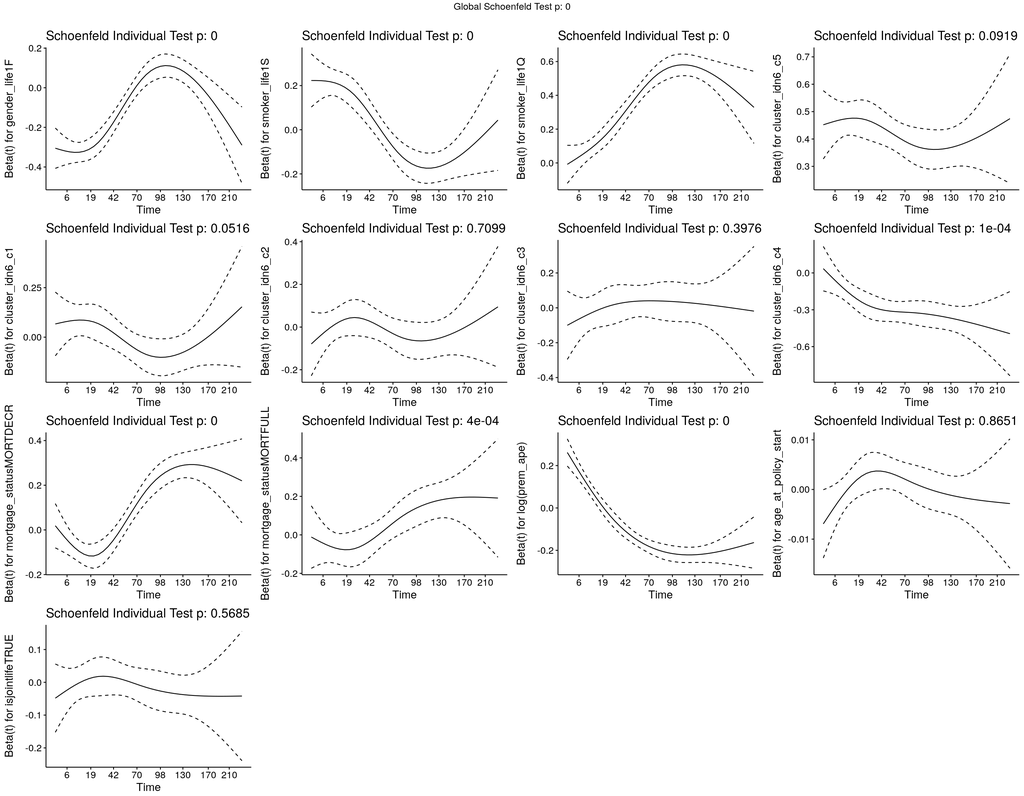

```r
basic_01_coxph %>% cox.zph() %>% ggcoxzph(resid = FALSE)
```

## 2.2 Investigate Strata

An additional way to account for time-varying effects of covariates is to stratify the baseline hazard rate: that is, we allow different levels of variables to have their own baseline that is modified by the proportional hazards variables.

```r
strat_01_coxph <- coxph(
    Surv(month_reached, lapsed) ~ strata(gender_life1) + smoker_life1 +
        cluster_id + mortgage_status + log(prem_ape) + age_at_policy_start +
        isjointlife
   ,data = use_train_tbl
)

strat_01_coxph %>% summary()
```

```
## Call:
## coxph(formula = Surv(month_reached, lapsed) ~ strata(gender_life1) +
##     smoker_life1 + cluster_id + mortgage_status + log(prem_ape) +
##     age_at_policy_start + isjointlife, data = use_train_tbl)
##
##   n= 50000, number of events= 19742
##
##                              coef exp(coef)  se(coef)     z Pr(>|z|)
## smoker_life1S            0.033174  1.033731  0.018945  1.75     0.08 .
## smoker_life1Q            0.325034  1.384078  0.017723 18.34  < 2e-16 ***
## cluster_idn6_c5          0.425516  1.530379  0.019640 21.67  < 2e-16 ***
## cluster_idn6_c1          0.005552  1.005568  0.025322  0.22     0.83
## cluster_idn6_c2         -0.011864  0.988206  0.023527 -0.50     0.61
## cluster_idn6_c3          0.006380  1.006400  0.030854  0.21     0.84
## cluster_idn6_c4         -0.260971  0.770303  0.028518 -9.15  < 2e-16 ***
## mortgage_statusMORTDECR  0.064155  1.066257  0.015615  4.11  4.0e-05 ***
## mortgage_statusMORTFULL  0.034303  1.034898  0.025558  1.34     0.18
## log(prem_ape)           -0.074761  0.927965  0.010093 -7.41  1.3e-13 ***
## age_at_policy_start      0.000296  1.000296  0.001083  0.27     0.78
## isjointlifeTRUE         -0.011967  0.988104  0.016399 -0.73     0.47
## ---
## Signif. codes:  0 '***' 0.001 '**' 0.01 '*' 0.05 '.' 0.1 ' ' 1
##
##                         exp(coef) exp(-coef) lower .95 upper .95
## smoker_life1S               1.034      0.967     0.996     1.073
## smoker_life1Q               1.384      0.723     1.337     1.433
## cluster_idn6_c5             1.530      0.653     1.473     1.590
## cluster_idn6_c1             1.006      0.994     0.957     1.057
## cluster_idn6_c2             0.988      1.012     0.944     1.035
## cluster_idn6_c3             1.006      0.994     0.947     1.069
## cluster_idn6_c4             0.770      1.298     0.728     0.815
## mortgage_statusMORTDECR     1.066      0.938     1.034     1.099
## mortgage_statusMORTFULL     1.035      0.966     0.984     1.088
## log(prem_ape)               0.928      1.078     0.910     0.947
## age_at_policy_start         1.000      1.000     0.998     1.002
## isjointlifeTRUE             0.988      1.012     0.957     1.020
##
## Concordance= 0.566  (se = 0.003 )
## Rsquare= 0.03   (max possible= 1 )
## Likelihood ratio test= 1534  on 12 df,   p=0
## Wald test            = 1579  on 12 df,   p=0
## Score (logrank) test = 1604  on 12 df,   p=0
```

```r
strat_01_coxph %>% tidy()   %>% print(digits = 2)
```

```
##                       term estimate std.error statistic p.value conf.low conf.high
## 1            smoker_life1S   0.0332    0.0189      1.75 8.0e-02  -0.0040    0.0703
## 2            smoker_life1Q   0.3250    0.0177     18.34 0.0e+00   0.2903    0.3598
## 3          cluster_idn6_c5   0.4255    0.0196     21.67 0.0e+00   0.3870    0.4640
## 4          cluster_idn6_c1   0.0056    0.0253      0.22 8.3e-01  -0.0441    0.0552
## 5          cluster_idn6_c2  -0.0119    0.0235     -0.50 6.1e-01  -0.0580    0.0342
## 6          cluster_idn6_c3   0.0064    0.0309      0.21 8.4e-01  -0.0541    0.0669
## 7          cluster_idn6_c4  -0.2610    0.0285     -9.15 0.0e+00  -0.3169   -0.2051
## 8  mortgage_statusMORTDECR   0.0642    0.0156      4.11 4.0e-05   0.0336    0.0948
## 9  mortgage_statusMORTFULL   0.0343    0.0256      1.34 1.8e-01  -0.0158    0.0844
## 10           log(prem_ape)  -0.0748    0.0101     -7.41 1.3e-13  -0.0945   -0.0550
## 11     age_at_policy_start   0.0003    0.0011      0.27 7.8e-01  -0.0018    0.0024
## 12         isjointlifeTRUE  -0.0120    0.0164     -0.73 4.7e-01  -0.0441    0.0202
```

```r
strat_01_coxph %>% glance()
```

```
##       n nevent statistic.log p.value.log statistic.sc p.value.sc statistic.wald
## 1 50000  19742        1534.5           0      1603.63          0        1578.67
##   p.value.wald r.squared r.squared.max concordance std.error.concordance  logLik    AIC
## 1            0 0.0302239      0.999515    0.566067             0.0028466 -190011 380045
##      BIC
## 1 380140
```

The concordance index for this is roughly the same, so we do the same for smoking status to see if we get any improvement.

```r
strat_02_coxph <- coxph(
    Surv(month_reached, lapsed) ~ strata(smoker_life1) + gender_life1 +
        cluster_id + mortgage_status + log(prem_ape) + age_at_policy_start +
        isjointlife
   ,data = use_train_tbl
)

strat_02_coxph %>% summary()
```

```
## Call:
## coxph(formula = Surv(month_reached, lapsed) ~ strata(smoker_life1) +
##     gender_life1 + cluster_id + mortgage_status + log(prem_ape) +
##     age_at_policy_start + isjointlife, data = use_train_tbl)
##
##   n= 50000, number of events= 19742
##
##                              coef exp(coef)  se(coef)     z Pr(>|z|)
## gender_life1F           -0.128167  0.879706  0.016013 -8.00  1.2e-15 ***
## cluster_idn6_c5          0.424188  1.528349  0.019641 21.60  < 2e-16 ***
## cluster_idn6_c1          0.005229  1.005242  0.025323  0.21     0.84
## cluster_idn6_c2         -0.012609  0.987470  0.023527 -0.54     0.59
## cluster_idn6_c3          0.005205  1.005219  0.030854  0.17     0.87
## cluster_idn6_c4         -0.261595  0.769822  0.028519 -9.17  < 2e-16 ***
## mortgage_statusMORTDECR  0.064633  1.066768  0.015616  4.14  3.5e-05 ***
## mortgage_statusMORTFULL  0.035024  1.035645  0.025558  1.37     0.17
## log(prem_ape)           -0.074716  0.928007  0.010091 -7.40  1.3e-13 ***
## age_at_policy_start      0.000319  1.000319  0.001083  0.29     0.77
## isjointlifeTRUE         -0.011997  0.988074  0.016400 -0.73     0.46
## ---
## Signif. codes:  0 '***' 0.001 '**' 0.01 '*' 0.05 '.' 0.1 ' ' 1
##
##                         exp(coef) exp(-coef) lower .95 upper .95
## gender_life1F               0.880      1.137     0.853     0.908
## cluster_idn6_c5             1.528      0.654     1.471     1.588
## cluster_idn6_c1             1.005      0.995     0.957     1.056
## cluster_idn6_c2             0.987      1.013     0.943     1.034
## cluster_idn6_c3             1.005      0.995     0.946     1.068
## cluster_idn6_c4             0.770      1.299     0.728     0.814
## mortgage_statusMORTDECR     1.067      0.937     1.035     1.100
## mortgage_statusMORTFULL     1.036      0.966     0.985     1.089
## log(prem_ape)               0.928      1.078     0.910     0.947
## age_at_policy_start         1.000      1.000     0.998     1.002
## isjointlifeTRUE             0.988      1.012     0.957     1.020
##
## Concordance= 0.566  (se = 0.004 )
## Rsquare= 0.024   (max possible= 0.999 )
## Likelihood ratio test= 1238  on 11 df,   p=0
## Wald test            = 1265  on 11 df,   p=0
## Score (logrank) test = 1287  on 11 df,   p=0
```

```r
strat_02_coxph %>% tidy()   %>% print(digits = 2)
```

```
##                       term estimate std.error statistic p.value conf.low conf.high
## 1            gender_life1F -0.12817    0.0160     -8.00 1.2e-15  -0.1596   -0.0968
## 2          cluster_idn6_c5  0.42419    0.0196     21.60 0.0e+00   0.3857    0.4627
## 3          cluster_idn6_c1  0.00523    0.0253      0.21 8.4e-01  -0.0444    0.0549
## 4          cluster_idn6_c2 -0.01261    0.0235     -0.54 5.9e-01  -0.0587    0.0335
## 5          cluster_idn6_c3  0.00521    0.0309      0.17 8.7e-01  -0.0553    0.0657
## 6          cluster_idn6_c4 -0.26160    0.0285     -9.17 0.0e+00  -0.3175   -0.2057
## 7  mortgage_statusMORTDECR  0.06463    0.0156      4.14 3.5e-05   0.0340    0.0952
## 8  mortgage_statusMORTFULL  0.03502    0.0256      1.37 1.7e-01  -0.0151    0.0851
## 9            log(prem_ape) -0.07472    0.0101     -7.40 1.3e-13  -0.0945   -0.0549
## 10     age_at_policy_start  0.00032    0.0011      0.29 7.7e-01  -0.0018    0.0024
## 11         isjointlifeTRUE -0.01200    0.0164     -0.73 4.6e-01  -0.0441    0.0201
```

```r
strat_02_coxph %>% glance()
```

```
##       n nevent statistic.log p.value.log statistic.sc p.value.sc statistic.wald
## 1 50000  19742       1238.34           0       1287.3          0         1265.4
##   p.value.wald r.squared r.squared.max concordance std.error.concordance  logLik    AIC
## 1            0 0.0244627       0.99929    0.566359            0.00371589 -180652 361326
##      BIC
## 1 361413
```

We quickly compare the models:

```r
list(basic_01_coxph = basic_01_coxph %>% glance
    ,strat_01_coxph = strat_01_coxph %>% glance
    ,strat_02_coxph = strat_02_coxph %>% glance) %>%
    bind_rows(.id = 'model') %>%
    select(model, n, nevent, concordance, std.error.concordance, logLik, AIC, BIC)
```

```
##            model     n nevent concordance std.error.concordance  logLik    AIC    BIC
## 1 basic_01_coxph 50000  19742    0.570497            0.00221415 -201949 403924 404027
## 2 strat_01_coxph 50000  19742    0.566067            0.00284660 -190011 380045 380140
## 3 strat_02_coxph 50000  19742    0.566359            0.00371589 -180652 361326 361413
```

We appear to gain very little from stratifying the risks for gender and smoking status, but we may look at this later once we use out-of-sample test data.

# 3 Using the Survival Model

The noisy nature of the outputs of survival model and the use of the concordance index mean it is difficult to measure the effectiveness of the models.

Considering this, we move on to possible uses of such a model in practice, potentially allowing us to construct some measure of model efficacy from how it is used.

## 3.1 Estimating Individual Survival Curves

We start with the simple use case of constructing individual survival curves for each policy. The Cox model outputs a proportional hazard for each policy and this is applied to the baseline hazard used. Having fit a Cox model, we use this to produce each curve.

The default baseline in R takes averages of all the variables in the dataset, including categorical variables. As these are encoded via integers we get the silly inclusion of floating-point numbers for the values on the baseline.

Instead, we construct our own baseline entry and we use that.

```r
lapse_baseline_tbl <- data_frame(
    gender_life1        = 'F'
   ,smoker_life1        = 'N'
   ,cluster_id          = 'n6_c0'
   ,mortgage_status     = 'TERM'
   ,isjointlife         = FALSE
   ,prem_ape            = use_train_tbl %>% pull(prem_ape) %>% mean
   ,age_at_policy_start = use_train_tbl %>% pull(age_at_policy_start) %>% mean
)
```

Using this data, we calculate the baseline hazard rate predicted from our Cox model.